# FunCC on CLR profiles and bicluster-specific depth

Île-de-France rail network - hourly validation profiles by day type

# 1 Setup

```r
library(roahd)
library(dplyr)
library(tidyr)
library(ggplot2)

theme_set(theme_minimal(base_size = 11))
set.seed(55702)
```

## 1.1 FunCC functions (loaded unchanged)

The FunCC functions are read from `biClustering_with_funCC.Rmd` **without modifying that file**: we take its R chunks and evaluate only the function definitions.

````r
load_function_defs <- function(rmd) {
  lines  <- readLines(rmd, encoding = "UTF-8", warn = FALSE)
  starts <- which(startsWith(lines, "```{r"))
  ends   <- which(trimws(lines) == "```")
  code <- unlist(lapply(starts, function(s) {
    e <- ends[ends > s][1]
    if (e > s + 1) lines[(s + 1):(e - 1)] else character(0)
  }))
  is_fun_def <- function(e) {
    is.call(e) &&
      (identical(e[[1]], as.name("<-")) || identical(e[[1]], as.name("="))) &&
      is.call(e[[3]]) && identical(e[[3]][[1]], as.name("function"))
  }
  env <- new.env()
  for (e in Filter(is_fun_def, as.list(parse(text = code)))) eval(e, envir = env)
  env
}

funcc <- load_function_defs("biClustering_with_funCC.Rmd")
ls(funcc)
````

```
##  [1] "add_cols"                     "add_rows"
##  [3] "compute_bicluster_properties" "compute_h_score"
##  [5] "compute_residual_scores"      "create_bicluster"
##  [7] "delete_cols"                  "delete_rows"
##  [9] "find_worst_node"              "get_scores"
## [11] "multiple_node_deletion"       "node_addition"
## [13] "plot_curves"                  "refine_bicluster"
## [15] "remove_node"                  "run_funCC"
## [17] "score_new_cols"               "score_new_rows"
## [19] "single_node_deletion"
```

## 1.2 Data

```r
load("array_3d_clr_service.rda")   # CLR on service hours (preprocessing.Rmd)
stations <- read.csv("stations.csv")

Z <- array_3d_clr_service          # stations x day types x hours (CLR)
hours <- as.integer(hours_service)
days  <- dimnames(Z)[[2]]
ids   <- dimnames(Z)[[1]]

# inverse CLR: back to shares (%) on the original scale
clr_inv <- function(z, total = 100) total * exp(z) / sum(exp(z))
S <- aperm(apply(Z, c(1, 2), clr_inv), c(2, 3, 1))
dimnames(S) <- dimnames(Z)
stopifnot(isTRUE(all.equal(S, array_3d_service)))   # inverse recovers the data

network_of <- function(id) {
  prefix <- sub("_[^_]+$", "", id)
  case_when(prefix == "100_110"       ~ "Metro",
            startsWith(prefix, "810") ~ "RER (RATP)",
            startsWith(prefix, "800") ~ "SNCF rail",
            TRUE                      ~ "Other")
}

station_info <- data.frame(station_id = ids) |>
  left_join(stations, by = "station_id") |>
  mutate(network = network_of(station_id),
         am_pm_WD = log(rowSums(S[, "WD", c("7", "8")]) /
                        rowSums(S[, "WD", c("17", "18")])))
name_of <- function(id) station_info$station_name[match(id, station_info$station_id)]

dim(Z)
```

```
## [1] 763   5  19
```

# 2 FunCC on CLR curves

The notebook’s `run_funCC()` is not finished yet. We follow the logic of the FunCC package (`funcc_biclust`), which works on **station × day-type cells** (the exact window search of the package is not reproduced):

1. keep a matrix of cells already covered by a bicluster;
2. for each combination of at least two day types, build the **maximal** window of stations whose cells are all uncovered on those day types (one window per combination, at least `min_rows` stations);
3. evaluate these windows in descending order of size: run the notebook’s `refine_bicluster()` (which shrinks the window) and keep the first result with at least `min_rows` stations and $H \le \delta$;
4. mark its cells as covered and repeat; stop when **no** window gives an acceptable bicluster.

A station can appear in several biclusters with different day types, but no cell is used twice. $\delta = 0.2\,H_{\text{full}}$ and $\theta = 1.3$ as in the notebook’s own test. `min_rows = 10` is our choice (the package allows 2): smaller groups are too small for depth-based tools.

```r
H_full   <- funcc$get_scores(Z)$H
theta    <- 1.3
min_rows <- 10

col_sets <- unlist(lapply(2:length(days), function(k)
  combn(days, k, simplify = FALSE)), recursive = FALSE)

candidate_windows <- function(covered) {
  wins <- lapply(col_sets, function(cs) list(
    rows = rownames(covered)[rowSums(covered[, cs, drop = FALSE]) == 0],
    cols = cs))
  wins <- Filter(function(w) length(w$rows) >= min_rows, wins)
  wins[order(-sapply(wins, function(w) length(w$rows) * length(w$cols)))]
}

run_funcc_cells <- function(Z, delta, max_bic = 30) {
  covered <- matrix(FALSE, dim(Z)[1], dim(Z)[2], dimnames = dimnames(Z)[1:2])
  bics <- list()
  n_errors <- 0
  repeat {
    if (length(bics) >= max_bic) break
    found <- FALSE
    for (w in candidate_windows(covered)) {
      b <- tryCatch(funcc$refine_bicluster(Z[w$rows, w$cols, , drop = FALSE],
                                           delta, theta),
                    error = function(e) {
                      message("FunCC refinement error: ", conditionMessage(e))
                      n_errors <<- n_errors + 1
                      NULL
                    })
      if (is.null(b) || dim(b)[1] < min_rows || dim(b)[2] < 2) next
      Hb <- funcc$get_scores(b)$H
      if (Hb > delta) next
      bics[[paste0("B", length(bics) + 1)]] <-
        list(rows = dimnames(b)[[1]], cols = dimnames(b)[[2]], H = Hb)
      covered[dimnames(b)[[1]], dimnames(b)[[2]]] <- TRUE
      found <- TRUE
      break
    }
    if (!found) break
  }
  list(biclusters = bics, covered = covered, n_errors = n_errors,
       hit_max_bic = length(bics) >= max_bic)
}

delta <- 0.2 * H_full
fit <- run_funcc_cells(Z, delta)
biclusters <- fit$biclusters
covered    <- fit$covered

c(H_full = round(H_full, 3), delta = round(delta, 3),
  refinement_errors = fit$n_errors, hit_max_bic = fit$hit_max_bic)
```

```
##            H_full             delta refinement_errors       hit_max_bic
##             2.790             0.558             0.000             0.000
```

```r
bic_table <- data.frame(
  bicluster = names(biclusters),
  stations  = sapply(biclusters, function(b) length(b$rows)),
  day_types = sapply(biclusters, function(b) paste(b$cols, collapse = ", ")),
  H = round(sapply(biclusters, function(b) b$H), 3)
)
bic_table
```

|  | bicluster | stations | day_types | H |
| --- | --- | --- | --- | --- |
| B1 | B1 | 650 | SA, SASH, SUPH, WD | 0.554 |
| B2 | B2 | 62 | WD, WDSH | 0.483 |
| B3 | B3 | 32 | SA, SUPH | 0.542 |
| B4 | B4 | 11 | SA, SASH | 0.555 |

```r
c(covered_cells = sum(covered), all_cells = length(covered),
  stations_in_several_biclusters =
    sum(table(unlist(lapply(biclusters, `[[`, "rows"))) > 1))
```

```
##                  covered_cells                      all_cells
##                           2810                           3815
## stations_in_several_biclusters
##                             34
```

```r
colSums(covered)
```

```
##   SA SASH SUPH   WD WDSH
##  693  661  682  712   62
```

```r
lapply(names(biclusters), function(k) {
  station_info |>
    filter(station_id %in% biclusters[[k]]$rows) |>
    summarise(bicluster = k, n = n(),
              Metro = sum(network == "Metro"),
              RER = sum(network == "RER (RATP)"),
              SNCF = sum(network == "SNCF rail"),
              Other = sum(network == "Other"),
              median_am_pm_WD = round(median(am_pm_WD), 2))
}) |> bind_rows()
```

| bicluster | n | Metro | RER | SNCF | Other | median_am_pm_WD |
| --- | --- | --- | --- | --- | --- | --- |
| B1 | 650 | 318 | 89 | 233 | 10 | 0.14 |
| B2 | 62 | 0 | 1 | 59 | 2 | 1.61 |
| B3 | 32 | 2 | 2 | 28 | 0 | 1.32 |
| B4 | 11 | 0 | 0 | 10 | 1 | 1.88 |

FunCC finds 4 biclusters and covers 74% of the station × day-type cells. **B1** is the large mainstream group (almost all Metro and RER stations, plus part of SNCF) on working days and weekends. **B2** is a group of **residential SNCF stations** on working days (with and without school holidays). **B3** collects the weekend profiles (Saturday and Sunday) of suburban SNCF stations left out of B1; 26 of its 32 stations are also in B2, now with their weekend days. **B4** is a small group on Saturdays (with and without school holidays).

## 2.1 Sensitivity to δ

The same procedure is repeated for several $\delta / H_{\text{full}}$ ratios. Stability of B2 and B3 is measured as the best cell-level Jaccard overlap between the reference bicluster and any bicluster found at that ratio.

```r
cells_of <- function(b) as.vector(outer(b$rows, b$cols, paste, sep = "|"))
best_jaccard <- function(ref, bics) {
  rc <- cells_of(ref)
  max(sapply(bics, function(b) {
    bc <- cells_of(b)
    length(intersect(rc, bc)) / length(union(rc, bc))
  }))
}

ratios <- c(0.10, 0.15, 0.20, 0.25, 0.30)
delta_fits <- lapply(ratios, function(r) {
  if (r == 0.2) fit else run_funcc_cells(Z, r * H_full)
})

data.frame(
  delta_ratio = ratios,
  biclusters = sapply(delta_fits, function(f) length(f$biclusters)),
  coverage_pct = sapply(delta_fits, function(f) round(100 * mean(f$covered), 1)),
  largest = sapply(delta_fits, function(f) {
    b <- f$biclusters[[which.max(sapply(f$biclusters, function(x)
      length(x$rows) * length(x$cols)))]]
    sprintf("%d x %d", length(b$rows), length(b$cols))
  }),
  jaccard_B2 = sapply(delta_fits, function(f)
    round(best_jaccard(biclusters$B2, f$biclusters), 2)),
  jaccard_B3 = sapply(delta_fits, function(f)
    round(best_jaccard(biclusters$B3, f$biclusters), 2)),
  errors = sapply(delta_fits, `[[`, "n_errors"),
  hit_max_bic = sapply(delta_fits, `[[`, "hit_max_bic")
)
```

| delta_ratio | biclusters | coverage_pct | largest | jaccard_B2 | jaccard_B3 | errors | hit_max_bic |
| --- | --- | --- | --- | --- | --- | --- | --- |
| 0.10 | 8 | 74.5 | 482 x 4 | 0.30 | 0.17 | 0 | FALSE |
| 0.15 | 11 | 73.2 | 517 x 4 | 0.50 | 0.30 | 0 | FALSE |
| 0.20 | 4 | 73.7 | 650 x 4 | 1.00 | 1.00 | 0 | FALSE |
| 0.25 | 5 | 91.9 | 647 x 5 | 0.81 | 0.61 | 0 | FALSE |
| 0.30 | 3 | 92.1 | 661 x 5 | 0.62 | 0.62 | 0 | FALSE |

The **overall structure is stable**: a dominant mainstream bicluster, a working-day group of residential suburban stations (B2-like) and a weekend group (B3-like) appear at every ratio. The **details are not**. For larger $\delta$, B2 is fairly stable (Jaccard 0.6-0.8) and the main bicluster also absorbs WDSH (coverage above 90%). For smaller $\delta$, the minor groups split into several pieces (Jaccard 0.2-0.5). B3 is less stable than B2. Conclusions about B2 and B3 should therefore stay at the level of “type of station”, not exact membership.

# 3 Bicluster-specific depth

From here on, each bicluster is analysed **with its own stations and its own day types**, as in Lab 2. Depths are computed on **CLR** curves; results are shown back on the **share scale** with the inverse CLR. Curves are back-transformed one by one (a CLR envelope is not a composition), and the central region is the pointwise range of the back-transformed deepest 50%.

```r
bic_fd <- lapply(biclusters, function(b) {
  setNames(lapply(b$cols, function(d) fData(hours, Z[b$rows, d, ])), b$cols)
})
bic_mfd <- lapply(biclusters, function(b) {
  mfData(hours, lapply(b$cols, function(d) Z[b$rows, d, ]))
})
n_panels <- sum(sapply(biclusters, function(b) length(b$cols)))
```

## 3.1 BD vs MBD inside each bicluster

```r
lapply(names(biclusters), function(k) {
  lapply(names(bic_fd[[k]]), function(d) {
    f <- bic_fd[[k]][[d]]
    data.frame(bicluster = k, day = d, N = f$N,
               distinct_BD = length(unique(BD(f))),
               distinct_MBD = length(unique(MBD(f)))) |>
      mutate(MBD_all_distinct = distinct_MBD == N)
  }) |> bind_rows()
}) |> bind_rows()
```

| bicluster | day | N | distinct_BD | distinct_MBD | MBD_all_distinct |
| --- | --- | --- | --- | --- | --- |
| B1 | SA | 650 | 1 | 650 | TRUE |
| B1 | SASH | 650 | 1 | 650 | TRUE |
| B1 | SUPH | 650 | 1 | 650 | TRUE |
| B1 | WD | 650 | 1 | 650 | TRUE |
| B2 | WD | 62 | 1 | 62 | TRUE |
| B2 | WDSH | 62 | 1 | 62 | TRUE |
| B3 | SA | 32 | 1 | 32 | TRUE |
| B3 | SUPH | 32 | 1 | 32 | TRUE |
| B4 | SA | 11 | 1 | 10 | FALSE |
| B4 | SASH | 11 | 1 | 11 | TRUE |

Inside every bicluster, as on the full data, **BD is constant** (one value). MBD gives every curve its own value except in one case (B4, SA: one tie among 11 curves). MBD is used below.

## 3.2 Bicluster medians and central regions

The **bicluster median** is the station with the highest `multiMBD` over the bicluster’s day types.

```r
bic_median <- sapply(names(biclusters), function(k) {
  biclusters[[k]]$rows[which.max(multiMBD(bic_mfd[[k]], weights = "uniform"))]
})

data.frame(bicluster = names(bic_median),
           median_station = name_of(bic_median),
           network = station_info$network[match(bic_median, station_info$station_id)])
```

| bicluster | median_station | network |
| --- | --- | --- |
| B1 | PTE D. VINCENN | Metro |
| B2 | BREUILLET BRUYE | SNCF rail |
| B3 | RAMBOUILLET | SNCF rail |
| B4 | MARLES EN BRIE | SNCF rail |

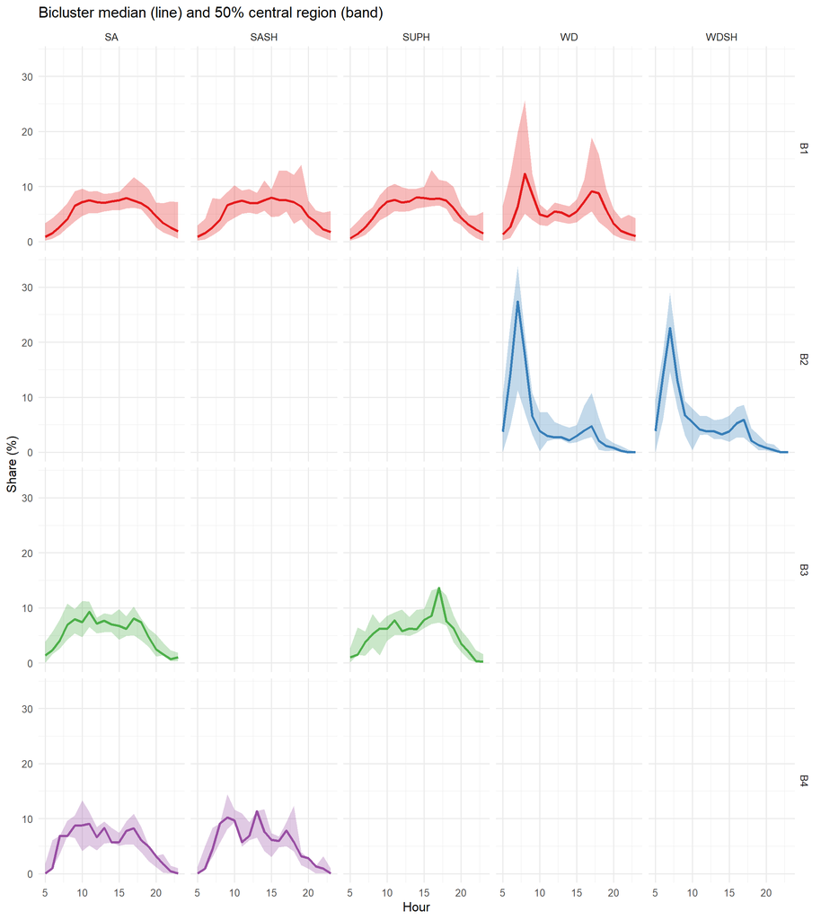

```r
region_df <- lapply(names(biclusters), function(k) {
  b <- biclusters[[k]]
  lapply(b$cols, function(d) {
    m <- MBD(bic_fd[[k]][[d]])
    central <- b$rows[m >= median(m)]          # deepest 50%
    data.frame(bicluster = k, day = d, hour = hours,
               lower = apply(S[central, d, ], 2, min),
               upper = apply(S[central, d, ], 2, max),
               median_share = S[bic_median[[k]], d, ])
  }) |> bind_rows()
}) |> bind_rows() |>
  mutate(day = factor(day, levels = days))

ggplot(region_df, aes(hour)) +
  geom_ribbon(aes(ymin = lower, ymax = upper, fill = bicluster), alpha = 0.3) +
  geom_line(aes(y = median_share, colour = bicluster), linewidth = 1) +
  facet_grid(bicluster ~ day) +
  scale_fill_brewer(palette = "Set1", guide = "none") +
  scale_colour_brewer(palette = "Set1", guide = "none") +
  labs(x = "Hour", y = "Share (%)",
       title = "Bicluster median (line) and 50% central region (band)")
```

**B1** (median: PTE D. VINCENN): double commuter peak on working days, flat broad profile on weekends. **B2** (median: BREUILLET BRUYE): an extreme **7h peak** (over a quarter of the day’s entries) and a weak evening, on WD and WDSH. **B3** (median: RAMBOUILLET): Saturday entries spread over the late morning, Sunday entries peaking at 17h (possibly return trips); profiles are more jagged than in B1, possibly because of lower volumes (the shares alone cannot show this). **B4** (median: MARLES EN BRIE): Saturday profiles of a few SNCF stations, with a morning plateau; very jagged (11 stations).

## 3.3 Functional boxplots inside each bicluster

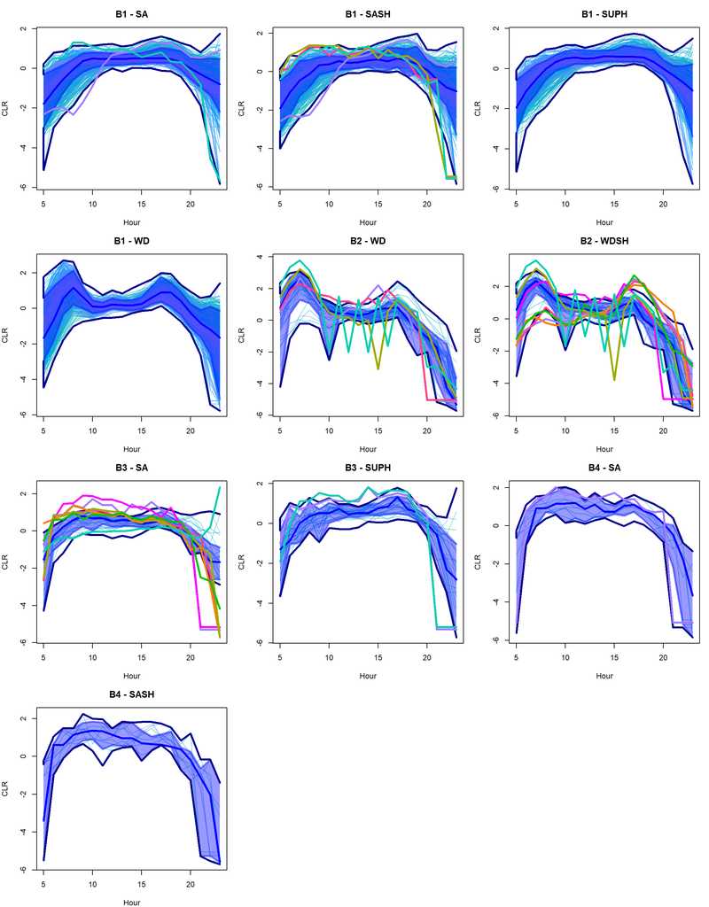

```r
old_par <- par(mfrow = c(ceiling(n_panels / 3), 3), mar = c(4, 4, 3, 1))
bic_fb <- list()
for (k in names(biclusters)) {
  for (d in biclusters[[k]]$cols) {
    bic_fb[[k]][[d]] <- fbplot(bic_fd[[k]][[d]], main = paste(k, "-", d),
                               xlab = "Hour", ylab = "CLR")
  }
}
par(old_par)
```

```r
lapply(bic_fb, function(x) sapply(x, function(fb) length(fb$ID_out)))
```

```
## $B1
##   SA SASH SUPH   WD
##    2    4    0    0
##
## $B2
##   WD WDSH
##    4    7
##
## $B3
##   SA SUPH
##    7    2
##
## $B4
##   SA SASH
##    1    0
```

B1 has almost no magnitude outliers (none on WD): FunCC already left the extreme stations out of it. The smaller biclusters have a few. In B3, **Plaine Stade de France** stands out on Saturdays with almost 40% of its entries at 23h, which is **potentially event-driven** (it is next to the stadium); an event calendar would be needed to confirm it.

## 3.4 Outliergram inside each bicluster

The outliergram is applied to **every day type** of every bicluster.

```r
bic_og <- lapply(names(biclusters), function(k) {
  lapply(bic_fd[[k]], function(f) outliergram(f, display = FALSE))
})
names(bic_og) <- names(biclusters)

lapply(bic_og, function(x) sapply(x, function(og) length(og$ID_outliers)))
```

```
## $B1
##   SA SASH SUPH   WD
##    0    0    0    0
##
## $B2
##   WD WDSH
##    7    7
##
## $B3
##   SA SUPH
##    0    1
##
## $B4
##   SA SASH
##    1    1
```

```r
outlier_tbl <- lapply(names(biclusters), function(k) {
  rows <- biclusters[[k]]$rows
  lapply(biclusters[[k]]$cols, function(d) {
    fb_ids <- bic_fb[[k]][[d]]$ID_out
    og_ids <- bic_og[[k]][[d]]$ID_outliers
    ids_k  <- union(fb_ids, og_ids)
    if (length(ids_k) == 0) return(NULL)
    data.frame(
      bicluster = k, day = d, station_id = rows[ids_k],
      station = name_of(rows[ids_k]),
      fbplot = ids_k %in% fb_ids,
      outliergram = ids_k %in% og_ids,
      peak_hour = hours[apply(S[rows[ids_k], d, , drop = FALSE], 1, which.max)],
      peak_share = round(apply(S[rows[ids_k], d, , drop = FALSE], 1, max), 1)
    )
  }) |> bind_rows()
}) |> bind_rows()
rownames(outlier_tbl) <- NULL

outlier_tbl |> filter(outliergram) |> select(-station_id)
```

| bicluster | day | station | fbplot | outliergram | peak_hour | peak_share |
| --- | --- | --- | --- | --- | --- | --- |
| B2 | WD | BONNIERES | TRUE | TRUE | 7 | 33.3 |
| B2 | WD | AVENUE DU PRESIDENT KENNEDY | FALSE | TRUE | 17 | 15.3 |
| B2 | WD | STADE DE FRANCE | FALSE | TRUE | 17 | 25.5 |
| B2 | WD | NANTERRE LA FOLIE RER E | FALSE | TRUE | 17 | 23.7 |
| B2 | WD | GARE DE L'EST | FALSE | TRUE | 17 | 20.3 |
| B2 | WD | NANTERRE UNIVER | FALSE | TRUE | 17 | 29.7 |
| B2 | WD | ACHERES GRAND | FALSE | TRUE | 7 | 14.2 |
| B2 | WDSH | STADE DE FRANCE | TRUE | TRUE | 17 | 26.2 |
| B2 | WDSH | NANTERRE LA FOLIE RER E | TRUE | TRUE | 17 | 24.3 |
| B2 | WDSH | GARE DE L'EST | TRUE | TRUE | 17 | 19.8 |

[output cut: 7 more lines]

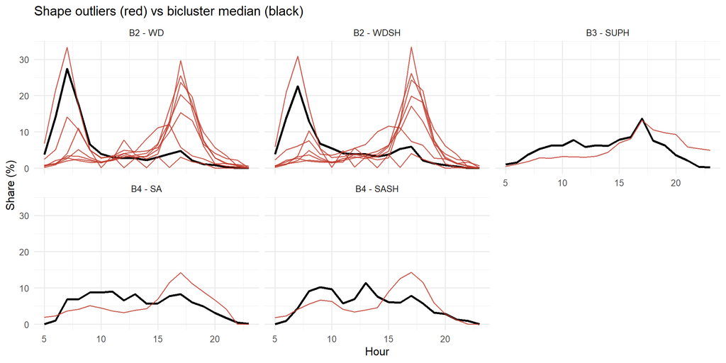

```r
og_flags <- outlier_tbl |> filter(outliergram)

if (nrow(og_flags) > 0) lapply(seq_len(nrow(og_flags)), function(i) {
  data.frame(panel = paste(og_flags$bicluster[i], "-", og_flags$day[i]),
             station = og_flags$station[i], hour = hours,
             share = S[og_flags$station_id[i], og_flags$day[i], ])
}) |> bind_rows() |>
  ggplot(aes(hour, share, group = station)) +
  geom_line(data = region_df |>
              mutate(panel = paste(bicluster, "-", day)) |>
              filter(panel %in% paste(og_flags$bicluster, "-", og_flags$day)),
            aes(hour, median_share, group = NULL), colour = "black",
            linewidth = 1) +
  geom_line(colour = "#c0392b", alpha = 0.8) +
  facet_wrap(~panel) +
  labs(x = "Hour", y = "Share (%)",
       title = "Shape outliers (red) vs bicluster median (black)")
```

## 3.5 Functional Spearman between day types inside each bicluster

```r
lapply(names(biclusters), function(k) {
  round(cor(sapply(bic_fd[[k]], MEI)), 2)
}) |> setNames(names(biclusters))
```

```
## $B1
##        SA SASH SUPH   WD
## SA   1.00 0.88 0.88 0.69
## SASH 0.88 1.00 0.85 0.62
## SUPH 0.88 0.85 1.00 0.64
## WD   0.69 0.62 0.64 1.00
##
## $B2
##        WD WDSH
## WD   1.00 0.87
## WDSH 0.87 1.00
##
## $B3
##        SA SUPH
## SA   1.00 0.93
## SUPH 0.93 1.00
##
## $B4
##        SA SASH
## SA   1.00 0.97
## SASH 0.97 1.00
```

```r
# check against roahd for the first pair of the first bicluster
k1 <- names(biclusters)[1]; d12 <- biclusters[[k1]]$cols[1:2]
c(manual = cor(MEI(bic_fd[[k1]][[d12[1]]]), MEI(bic_fd[[k1]][[d12[2]]])),
  roahd  = cor_spearman(as.mfData(list(bic_fd[[k1]][[d12[1]]],
                                       bic_fd[[k1]][[d12[2]]])),
                        ordering = "MEI"))
```

```
##    manual     roahd
## 0.8841026 0.8841026
```

In B1, rankings are very similar across weekend day types (≈ 0.85-0.88) and less similar between WD and weekends (≈ 0.6-0.7). WD and WDSH agree strongly in B2 (0.87); the weekend day types agree strongly in B3 (0.93) and B4 (0.97). These are associations, not tests.

## 3.6 Comparing biclusters: DD-plot

B1 and B2 are compared on working days, the day type they share.

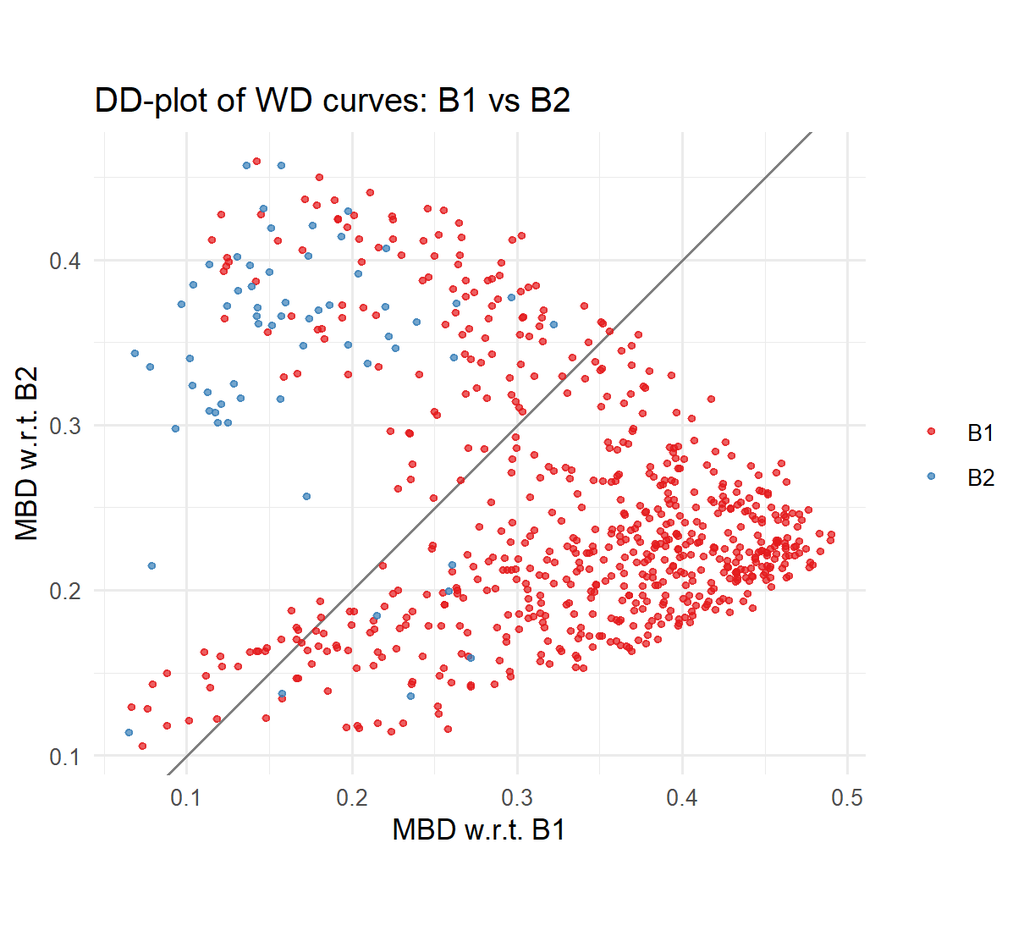

```r
r1 <- biclusters$B1$rows; r2 <- biclusters$B2$rows
pooled <- rbind(Z[r1, "WD", ], Z[r2, "WD", ])
data.frame(
  depth_wrt_B1 = MBD_relative(pooled, Z[r1, "WD", ]),
  depth_wrt_B2 = MBD_relative(pooled, Z[r2, "WD", ]),
  group = rep(c("B1", "B2"), c(length(r1), length(r2)))
) |>
  ggplot(aes(depth_wrt_B1, depth_wrt_B2, colour = group)) +
  geom_abline(slope = 1, intercept = 0, colour = "grey50") +
  geom_point(size = 1, alpha = 0.7) +
  coord_equal() +
  scale_colour_brewer(palette = "Set1") +
  labs(x = "MBD w.r.t. B1", y = "MBD w.r.t. B2", colour = NULL,
       title = "DD-plot of WD curves: B1 vs B2")
```

B2 stations lie well above the diagonal (deep in B2, shallow in B1): the two biclusters have different working-day profiles. Some B1 stations also lie above the diagonal, so **B1 contains B2-like stations**: on working days B1 is heterogeneous, which a smaller $\delta$ might split. Exploratory, not a test.

# 4 Uncovered cells

```r
colSums(!covered)          # uncovered station x day-type cells per day type
```

```
##   SA SASH SUPH   WD WDSH
##   70  102   81   51  701
```

```r
fb_all_wd <- ids[fbplot(fData(hours, Z[, "WD", ]), display = FALSE)$ID_out]
wd_uncovered <- ids[!covered[, "WD"]]

c(WD_cells_uncovered = length(wd_uncovered),
  global_WD_fbplot_flags = length(fb_all_wd),
  flagged_and_uncovered = sum(fb_all_wd %in% wd_uncovered))
```

```
##     WD_cells_uncovered global_WD_fbplot_flags  flagged_and_uncovered
##                     51                     20                     15
```

Most WDSH cells stay uncovered: once B1 has used the other day types of its stations, WDSH alone cannot form a bicluster (at least 2 day types are required). On working days, 15 of the 20 stations flagged by the global WD functional boxplot are not covered by any bicluster: **FunCC and depth agree** on which stations are atypical.

# 5 Summary

```r
data.frame(
  bicluster = names(biclusters),
  stations = sapply(biclusters, function(b) length(b$rows)),
  day_types = sapply(biclusters, function(b) paste(b$cols, collapse = ", ")),
  median_station = name_of(bic_median),
  fbplot_flags = sapply(names(biclusters), function(k)
    sum(outlier_tbl$bicluster == k & outlier_tbl$fbplot)),
  outliergram_flags = sapply(names(biclusters), function(k)
    sum(outlier_tbl$bicluster == k & outlier_tbl$outliergram))
)
```

|  | bicluster | stations | day_types | median_station | fbplot_flags | outliergram_flags |
| --- | --- | --- | --- | --- | --- | --- |
| B1 | B1 | 650 | SA, SASH, SUPH, WD | PTE D. VINCENN | 6 | 0 |
| B2 | B2 | 62 | WD, WDSH | BREUILLET BRUYE | 11 | 14 |
| B3 | B3 | 32 | SA, SUPH | RAMBOUILLET | 9 | 1 |
| B4 | B4 | 11 | SA, SASH | MARLES EN BRIE | 1 | 2 |